# Lab 7

Blue Team: Matt Lawson, Brandon Bowen, Bing Mitchell, Nick Zimmerman

3/1/2019

# Setup

```r
  energy <- read_delim("/Users/Matt/Google Drive/A Spring 2019/Data Science/household_power_consumption.txt", delim=";",
    col_types=cols( Date = col_date(format="%d/%m/%Y"))
  )
energy <- na.omit(energy)
```

## Matt

### How does the average energy used per day change throughout the year? Does it differ from year to year?

I calculatd the average `global_active_power` per day for every day in the dataset(~4 years). Then, I converted the month and day into `day_of_year`. The final step was to split up the data by `year` and plot all of the years together. (Note: I removed 2006 data because it wasn’t a full year.)

```r
byDay <- energy %>%
  filter(!format(Date, '%Y') == 2006) %>%
  group_by(Date) %>%
  summarize(average= mean(Global_active_power), time = Time[which.max(Global_active_power)]) %>%
  mutate(Year=as.factor(format(Date, '%Y')), Month=as.numeric(format(Date,'%m')), DayOfYear=as.numeric(format(Date,'%j')))
```

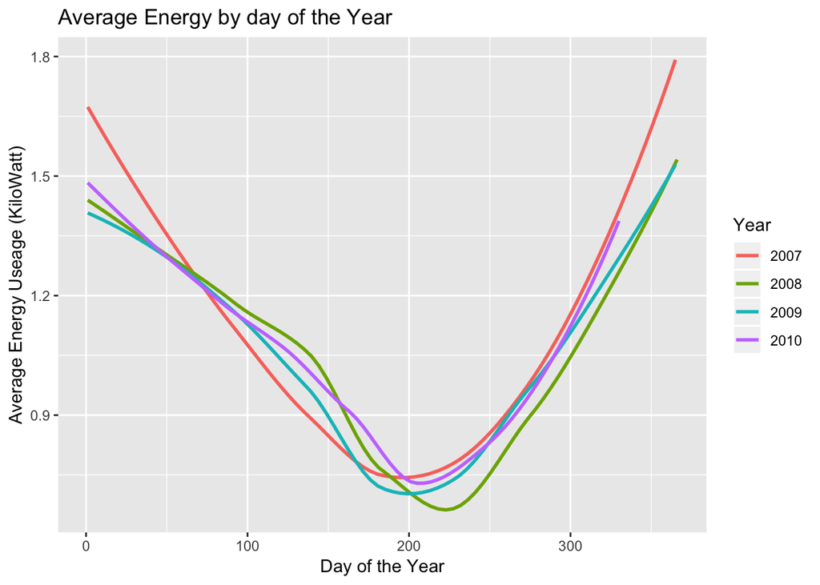

```r
ggplot(byDay, aes(x=DayOfYear, y=average, color=Year)) +
  geom_smooth(se=FALSE) +
  labs(title="Average Energy by day of the Year", x="Day of the Year", y="Average Energy Useage (KiloWatt)")
```

```r
(mean(energy$Global_active_power))
```

```
## [1] 1.091615
```

It is easy to see that all of the years behave similarly. The energy useage decreases (linearly) until about day 200 (July 19), and then it begins to increase (linearly). It is important to note the summertime is when the energy useage is the least. One possible reason for this is that in the summer, people are outside more often than in the winter time. They are more likely to be outside during the day, eat out at night, and they wont need to use the lights as often. In the winter, people are more likely to be inside their house with the heat on. This could explain the shape of the graph. The average energy useage for the entire dataset is 1.09 Kilowatts.

## Bing

```r
# library(lubridate)
# energy <- read_delim("/Users/Matt/Google Drive/A Spring 2019/Data Science/household_power_consumption.txt", delim=";",
#     col_types=cols( Date = col_date(format="%d/%m/%Y"))
#   )
# energy <- na.omit(energy)

#head(energy)


energy <- energy %>% mutate(month = month(ymd(Date)))

summer <- energy %>% filter((month > 5 & month < 9))
winter <- energy %>% filter((month > 11 | month < 3))

sVolt <- summarise(summer, Avg = mean(Voltage))
wVolt <- summarise(winter, Avg = mean(Voltage))

#head(sVolt)
#head(wVolt)



VOLT <- bind_rows(sVolt, wVolt)

Season <- tribble(~season,
                  "Summer",
                  "Winter")

head(Season)
```

```
## # A tibble: 2 x 1
##   season
##   <chr>
## 1 Summer
## 2 Winter
```

```r
head(VOLT)
```

```
## # A tibble: 2 x 1
##     Avg
##   <dbl>
## 1  240.
## 2  242.
```

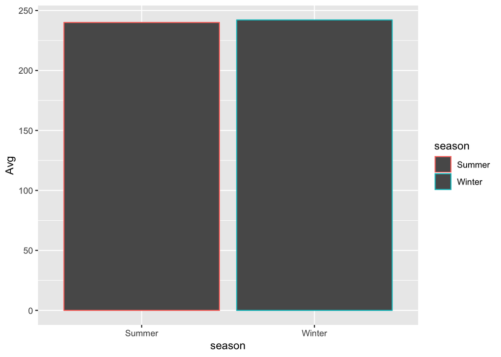

```r
Season <- cbind(Season, VOLT)

ggplot(data = Season) + geom_col(mapping = aes(x = season, y = Avg, color = season))
```

I wanted to see if more electrcity was used during or summer or winter, because there are certain applications that get used during certain months such as heat vs AC. After conducting my research we can see that slightly more volatge is used during the winter, but not significantly more than the summer. So the answer to my question that while different applications are used during different seasons, the electric use remains about the same.

## Brandon

### What appliances causes the most energy usage during the year? What times are they most active?

```r
power <- energy %>%
  filter(!format(Date, '%Y') == 2006) %>%
  group_by(Date) %>%
  summarize(average = mean(Global_active_power), average1 = mean(Sub_metering_1), average2 = mean(Sub_metering_2), average3 = mean(Sub_metering_3), time = Time[which.max(Global_active_power)]) %>%
  mutate(Year=as.factor(format(Date, '%Y')), Month=as.numeric(format(Date,'%m')), dayofyear=as.numeric(format(Date,'%j'))) %>%
  mutate(allaverage = average1, average2, average3)
```

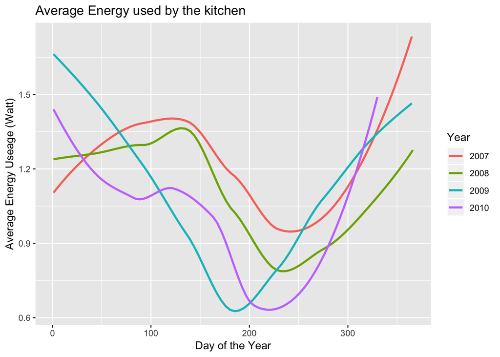

```r
 ggplot(power, aes(x = dayofyear, y = average1, color = Year )) +
  geom_smooth(se = FALSE) +
  labs(title="Average Energy used by the kitchen", x="Day of the Year", y="Average Energy Useage (Watt)")
```

[figure not shown]

```r
ggplot(power, aes(x = dayofyear, y = average2, color = Year )) +
  geom_smooth(se = FALSE) +
   labs(title="Average Energy used by the kitchen", x="Day of the Year", y="Average Energy Useage (Watt)")
```

[figure not shown]

```r
ggplot(power, aes(x = dayofyear, y = average3, color = Year )) +
  geom_smooth(se = FALSE) +
   labs(title="Average Energy used by the kitchen", x="Day of the Year", y="Average Energy Useage (Watt)")
```

```r
(mean(energy$Sub_metering_1))
```

```
## [1] 1.121923
```

```r
(mean(energy$Sub_metering_2))
```

```
## [1] 1.29852
```

```r
(mean(energy$Sub_metering_3))
```

```
## [1] 6.458447
```

From the graphs it can be seen that the electric heater and air conditioner take up most of the energy usage.Besides the year 2007 the litchen and laundry room have around the same amount of energy use. While the energy usage drops drasticaly during the middle of the year this could be due to the summer months. People going on vacation and not using their electronics as much.lastly the energy usage goes up during the winter months. Since it’s winter the electric heater would be used more often, People would cook more since it would be too cold to go outside and would use the laundry more often to was their warmer clothes. All of these could contribute to the higher energy usage during the winter months. I came up with question by determing if there was any factor to the energy usage for the house. Then I seperated out the averages for the different rooms and plotted them on three seprate graphs. Showing each average throught a whole year starting from 2007 since 2006 only had partial data.

## Nick

### How does the energy usage during one hour vary as the years go by?

I calculated the average Global_active_power per hour of each day. Then I choose one hour (5pm) and graphed the average Global_active_power at 5pm for each day in the data.

```r
byHour <- energy %>%
  filter(!format(Date, '%Y') == 2006) %>%
  separate(Time, into = c("Hour","Minute")) %>%
  group_by(Date,Hour) %>%
  summarise(Global_active_power = mean(Global_active_power))
```

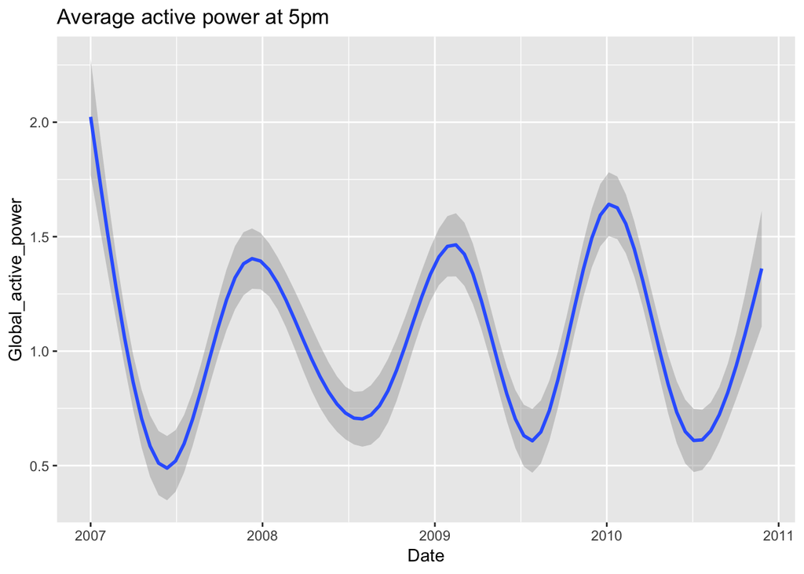

```r
ggplot(filter(byHour, Hour == 17))+
  geom_smooth(mapping = aes(x=Date,y=Global_active_power)) +
  labs(title="Average active power at 5pm")
```